# Portfolio 1 - Ethanol

Angelina Allen

2024-05-07

## Introduction

After cleaning, the gas_mileage_data.csv data set consists of 347 observations from data collected on a 2011 Toyota Sienna. The data was collected by recording the number of miles on the trip meter(then resetting the trip meter), the amount of gas, and the type of gas in terms of the octane and ethanol percentage. In the data collection, the goal was to see how the miles per gallon are affected by the presence of ethanol. In particular, this experiment aims to answer the scientific question, “How is gas mileage (miles per gallon) different when using gas with no ethanol compared to gas with 10% ethanol?”

## Data

The collected data has 347 observations with seven variables (date, mpg, gallons, USD(price), miles, ethanol, and octane). For this specific question, we will only look at the mpg and ethanol variables. The table below provides a summary statics of the two variables. Showing the total observation of the data, the mean, median, min, and max of mpg, and the counts of the presence of ethanol.

Summary Statistic of mpg and ethanol variables

| Total Obs | mean(mpg) | median(mpg) | min(mpg) | max(mpg) | Yes(ethanol) | No(ethanol) |
| --- | --- | --- | --- | --- | --- | --- |
| 347 | 19.43338 | 19.30846 | 8.508946 | 39.08611 | 229 | 118 |

The figure below displays a box plot with jitter points of the miles per gallon versus 10% ethanol. When comparing the presence of 10% ethanol and no presence, this figure suggests that the presence of no 10% ethanol has a slightly higher average mpg than the presence of ethanol. Another notable thing here is that because we are doing a box plot with jitter it records the outliers twice.

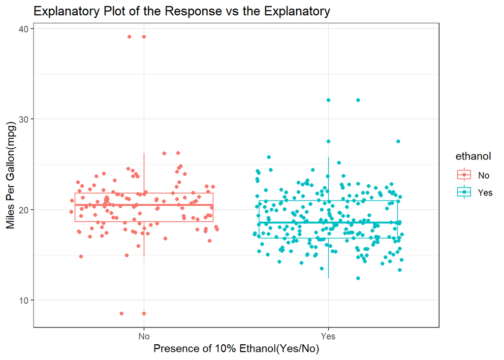

## Results

Since we are working with gas mileage as our response this variable is continuous and a simple linear regression makes the most sense. There will also be no interaction since we only have one explanatory variable.
The Simple Linear Regression model assumes:
$$Y_i \stackrel{ind}{\sim} N(\beta_0 +
\beta_1X_i,\sigma^2)$$
for $i = 1$,…, n or , equivalently,
$$Y_i =
\beta_0 + \beta_1X_i + \epsilon_i$$
$$\epsilon_i\stackrel{ind}{\sim}
N(0,\sigma^2)$$
where, for observations $i$,

- $Y_i$ is the value of the response variable
- $X_i$ is the value of the explanatory variable
- $\epsilon_i$ is the error

The model parameters are

- the intercept $\beta_0$
- the slop $\beta_1$
- the error variance $\sigma^2$

Where the response variable ($Y_i$) is the miles per gallon, the explanatory($X_i$) is the presence of 10% ethanol (Yes for ethanol, No for no ethanol), and the error term ($\epsilon_i$) assumed to follow a normal distribution with mean 0 and variance $\sigma^2$.

Below is a plot of the estimated mean number of gas mileage and 95% confidence intervals. As we saw with the original data, the mean gas mileage for no ethanol is slightly higher than the mean gas mileage for the presence of ethanol.

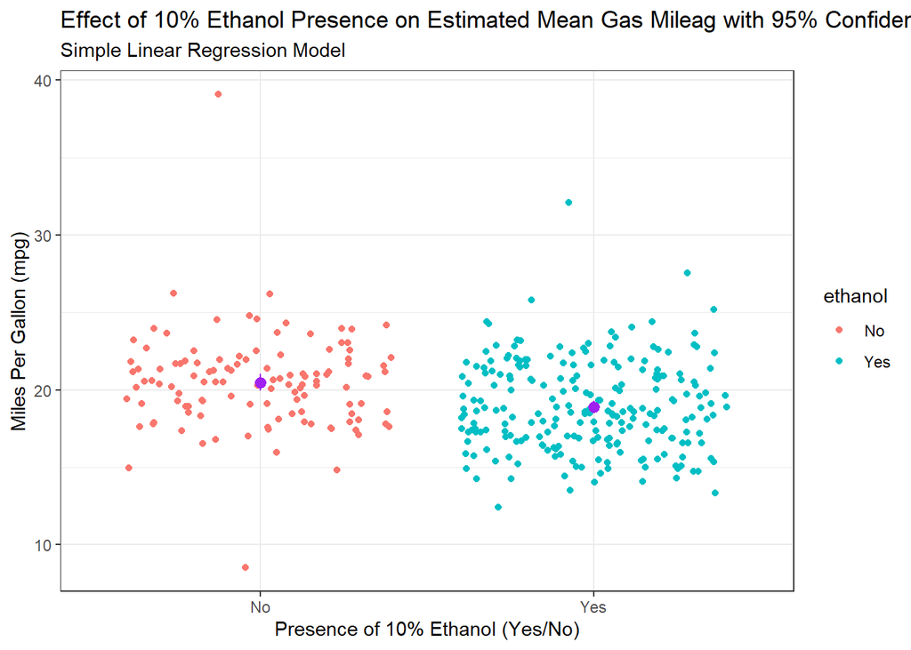

Additionally, we calculated the estimate with uncertainty for the difference in gas mileage when there is 10% ethanol vs when there isn’t. The interval is -2.250215, -0.914137. Since the confidence interval does not include zero there is a statistically significant difference in mean gas mileage between presence of 10% ethanol and no presence of 10% ethanol.

## Discussion

The data was collected on a 2011 Toyota Sienna and our goal was to see how the miles per gallon are affected by the presence of 10% ethanol. Precisely, we want to explore the difference between no presence and the presence of 10% ethanol. We found that with no presence of 10% ethanol there is a higher average of gas mileage than there was for a presence of 10% ethanol. A 95% confidence interval for the mean gas mileage with no 10% ethanol is (19.9458965, 21.0091589). Additionally, a 95% confidence interval for the mean gas mileage with a presence of 10% ethanol is (18.5137294, 19.276974).

From the information about our data collection, it needs to be clarified if it is randomly assigned. If data on ethanol presence and gas mileage were collected on random cars and ethanol presence was randomly assigned, then we can claim that the presence of 10% ethanol caused the difference in gas mileage. Since the car and 10% ethanol presence are not a random sample from any population, we must be careful in extending these results to a larger population.